# Quantitative Analysis

#### Computational Investing Chris Harris 11 Nov 2014

## Introduction

#### In this class conducted by Tucker Balch, Georgia Tech, the first initiative involves developing an investment strategy, which has the ability to survive backtesting. For the time period concerned, Jan 2008 to Dec 2009, the market underwent a major downdraft in response to the subprime mortgage crisis. However, as this data presents, a simple strategy of buying stocks within the S&P 500 index, which dipped below $ 5 per share, a critical margin level requirement, for a holding period of just 5 trading days, could have kept an investment portfolio in the black throughout the ‘Great Recession’, without a significant drawdown. If a stock repeats this price pattern, it can be purchased multiple times. For simplicity, no portfolio scaling takes place, as only 100 shares are purchased for each event, regardless of investment capital size. The main goal of this study is to compare one strategy’s success relative to another, so portfolio size should not factor into the equation. Through this exercise and subsequent examples presented throughout the class, I became indoctrinated into the hedge fund manager’s circle. Program development procedes according to the following scheme: *event.py* identifies times when a stock drops below $ 5 / share within the S&P 500 index *marketsim.py* generates buy and sell orders to align with a 5 trading day holding period *analyze.py* determines profits and losses based on buy / sell orders and porfolio capital funding

## Python Code

```
event.py:

import os
import shutil
import math
import matplotlib as mpl
import matplotlib.pyplot as plt

# obtain market data
def acquire(sym,interval):

    if not os.path.isfile("../data/%s.csv" %sym):
        shutil.copy("../QSTK-0.2.8/QSTK/QSData/Yahoo/%s.csv" %sym, "../data")
    data   = open("../data/%s.csv" %sym,'r')
    stream = data.read()
    data.close()

    field  = 7
    entry  = ""
    val    = []
    matrix = []

    for ch in stream:
        entry = entry + ch
        if ch==',' or ch=='\n':
            if len(entry)>1:
                val.append(entry[:-1])
            entry = ""
        if len(val)>=field:
            if interval[1] >= val[0] >= interval[0]:
                matrix.append(val)
            val = []

    matrix.sort()
    return matrix

def plot(label,mean,std,delta):

    X  = []
    Y  = []
```

[output cut: 113 more lines]

```
    output.close()

    # display results
    print("\nEvent count = %i\n" %ev)
    plot("Event",mean,std,delta)

def main():

    ofile    = "orders.csv"
    spfile   = "sp5002012.txt"
    interval = ["2008-01-03","2009-12-28"]

    event(spfile,interval,ofile)

main()
```

## Python Code

```
marketsim.py:

import sys
import os
import shutil

# obtain market data
def acquire(sym,interval):

    if not os.path.isfile("../data/%s.csv" %sym):
        shutil.copy("../QSTK-0.2.8/QSTK/QSData/Yahoo/%s.csv" %sym, "../data")
    data   = open("../data/%s.csv" %sym,'r')
    stream = data.read()
    data.close()

    field  = 7
    entry  = ""
    val    = []
    matrix = []

    for ch in stream:
        entry = entry + ch
        if ch==',' or ch=='\n':
            if len(entry)>1:
                val.append(entry[:-1])
            entry = ""
        if len(val)>=field:
            if interval[1] >= val[0] >= interval[0]:
                matrix.append(val)
            val = []

    matrix.sort()
    return matrix

def gather(orders):

    # read order file
    data = open(orders,'r')
    stream = data.read()
    data.close()
```

[output cut: 67 more lines]

```
    output = open("values.csv",'w')
    output.write(stream)
    output.close()
    print("\ninitial = %.8g\norders  = %s\nvalues  = %s\n" %(initial,orders,values))

def main():

    initial = float(sys.argv[1])
    orders = sys.argv[2]
    values = sys.argv[3]
    interval = ["2008-01-03","2009-12-28"]

    execute(orders,initial,interval,values)

main()
```

## Python Code

```
analyze.py:

import sys
import os
import shutil
import math
import matplotlib as mpl
import matplotlib.pyplot as plt

# obtain market data
def acquire(sym,interval):

    if not os.path.isfile("../data/%s.csv" %sym):
        shutil.copy("../QSTK-0.2.8/QSTK/QSData/Yahoo/%s.csv" %sym, "../data")
    data   = open("../data/%s.csv" %sym,'r')
    stream = data.read()
    data.close()

    field  = 7
    entry  = ""
    val    = []
    matrix = []

    for ch in stream:
        entry = entry + ch
        if ch==',' or ch=='\n':
            if len(entry)>1:
                val.append(entry[:-1])
            entry = ""
        if len(val)>=field:
            if interval[1] >= val[0] >= interval[0]:
                matrix.append(val)
            val = []

    matrix.sort()
    return matrix

def finance(matrix):

    tsh = 252.0
```

[output cut: 164 more lines]

```

    r,dr = finance(rdata)
    f    = ("\n$SPX:\n\ntotal return       = %.4g\nmean daily return  = %.4g\nstandard deviation = %.4g\nSharpe ratio       = %.4g\n"
    %(r[0],r[1],r[2],r[3]))
    print(f)
    plot("Portfolio",symbol,rdata,vdata,p)

def main():

    values = sys.argv[1]
    symbol = sys.argv[2]

    analyze(values,symbol)

main()
```

## Results

```
$ python event.py

period: 2008-01-03 to 2009-12-28
        501 overall trade days

omit:   BWA
        CFN
        DPS
        KMI
        LO
        LYB
        MJN
        MPC
        PEG
        PM
        PSX
        QEP
        SNI
        TRIP
        V
        WPX
        XYL

Event count = 193

$ python marketsim.py 10000 orders.csv values.csv

2008-02-06      LSI     Buy     100
2008-02-13      LSI     Sell    100
2008-02-19      LSI     Buy     100
2008-02-26      LSI     Sell    100
2008-02-28      THC     Buy     100
2008-03-06      THC     Buy     100
2008-03-06      THC     Sell    100
2008-03-07      LSI     Buy     100
2008-03-13      THC     Sell    100
2008-03-14      LSI     Buy     100
                ...
2009-10-28      LSI     Buy     100
2009-10-30      RF      Buy     100
```

[output cut: 16 more lines]

```
2009-12-28      13590

Portfolio:

total return       = 0.359
mean daily return  = 0.0006709
standard deviation = 0.01091
Sharpe ratio       = 0.9762

$SPX:

total return       = -0.2207
mean daily return  = -0.0002553
standard deviation = 0.022
Sharpe ratio       = -0.1842
```

#### **Figure 1**: Event Mean Return with Standard Deviation Range Bars

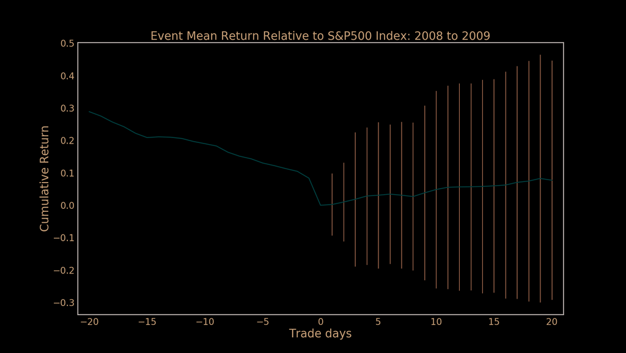

#### **Figure 2**: Event Mean Return

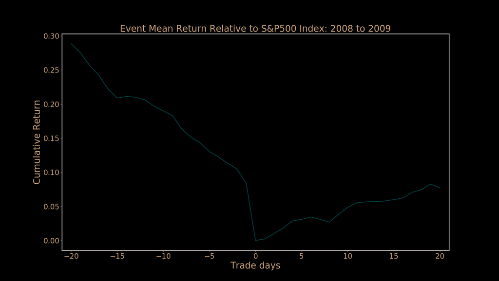

#### **Figure 3**: Portfolio Performance

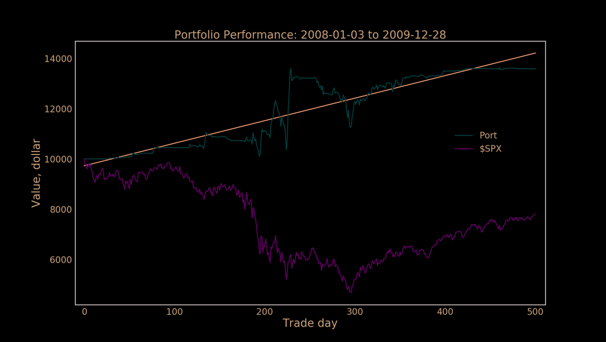